# Chapter 10 Linear Regression: Computer Task Solutions

Richard Wilkinson

## Computer tasks

##### Q1

The gasoline dataset in the `pls` dataset consists of data on 60 different gasoline samples. For each sample, the near-infra-read (NIR) spectrum has been measured, which consists of measurements at 401 different wavelengths.

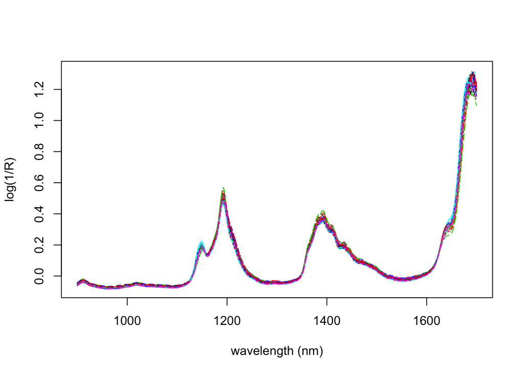

```r
library(pls)
data(gasoline)
matplot(seq(900,1700,2),t(gasoline$NIR), type='l', ylab='log(1/R)', xlab='wavelength (nm)')
```

Also recorded is the octane number of each sample. We will use the NIR measurements to predict the octane number of each sample. Note that here $n=60$ and $p=401$, so we have many more covariates than samples.

1. Start by using the `lm` command to predict the octane number from the NIR spectra.

```r
gas.lm <- lm(octane~NIR, data=gasoline)
```

What happens? How many of the coefficients are estimated?

The covariate matrix $\mathbf X$ is $60\times 401$. The naive OLS estimator
$$(\mathbf X^\top \mathbf X)^{-1}\mathbf X^\top \mathbf y$$
involves the inverse of $(\mathbf X^\top \mathbf X)^{-1}$, which in this case is a $401 \times 401$ matrix of rank at most 60. Thus it is not invertible.

```r
coef(gas.lm)[1:100]
```

```
## (Intercept)   NIR900 nm   NIR902 nm   NIR904 nm   NIR906 nm   NIR908 nm
##    483.1856 -24260.3171 -18267.4559  15989.9042 -14110.4715  21111.9165
##   NIR910 nm   NIR912 nm   NIR914 nm   NIR916 nm   NIR918 nm   NIR920 nm
##  17721.0489  -6133.9016   -486.7148   6511.4456  -4253.3466 -32548.3782
##   NIR922 nm   NIR924 nm   NIR926 nm   NIR928 nm   NIR930 nm   NIR932 nm
##  24675.4370   1871.8213 -22699.8907  37521.8093  -4189.9107  -1284.8007
##   NIR934 nm   NIR936 nm   NIR938 nm   NIR940 nm   NIR942 nm   NIR944 nm
##  26831.7811  24394.2217   6157.5540 -62075.6004 -76762.3711  51875.9328
##   NIR946 nm   NIR948 nm   NIR950 nm   NIR952 nm   NIR954 nm   NIR956 nm
## -20214.4881 -26627.6883  37529.8105 -15734.7199  87375.7664 -39180.4653
##   NIR958 nm   NIR960 nm   NIR962 nm   NIR964 nm   NIR966 nm   NIR968 nm
## -23517.7801  21175.4795  28376.4367  56671.2136 -46634.0914 -17618.9349
##   NIR970 nm   NIR972 nm   NIR974 nm   NIR976 nm   NIR978 nm   NIR980 nm
##  76039.4972  -7797.7093 -68962.8609 -54896.1171  18649.6597  22834.2249
##   NIR982 nm   NIR984 nm   NIR986 nm   NIR988 nm   NIR990 nm   NIR992 nm
## -57093.0827  18209.8438  37029.9733   8335.4738  17109.9673 -34620.8186
##   NIR994 nm   NIR996 nm   NIR998 nm  NIR1000 nm  NIR1002 nm  NIR1004 nm
## -91225.9688  96890.9404  20509.7228  53535.2166   4488.3995  49531.3777
##  NIR1006 nm  NIR1008 nm  NIR1010 nm  NIR1012 nm  NIR1014 nm  NIR1016 nm
## -65202.7703   9533.3868 -88366.9080  45037.8874  15693.9422 -28076.9493
##  NIR1018 nm  NIR1020 nm  NIR1022 nm  NIR1024 nm  NIR1026 nm  NIR1028 nm
##          NA          NA          NA          NA          NA          NA
##  NIR1030 nm  NIR1032 nm  NIR1034 nm  NIR1036 nm  NIR1038 nm  NIR1040 nm
##          NA          NA          NA          NA          NA          NA
##  NIR1042 nm  NIR1044 nm  NIR1046 nm  NIR1048 nm  NIR1050 nm  NIR1052 nm
##          NA          NA          NA          NA          NA          NA
##  NIR1054 nm  NIR1056 nm  NIR1058 nm  NIR1060 nm  NIR1062 nm  NIR1064 nm
##          NA          NA          NA          NA          NA          NA
##  NIR1066 nm  NIR1068 nm  NIR1070 nm  NIR1072 nm  NIR1074 nm  NIR1076 nm
##          NA          NA          NA          NA          NA          NA
##  NIR1078 nm  NIR1080 nm  NIR1082 nm  NIR1084 nm  NIR1086 nm  NIR1088 nm
##          NA          NA          NA          NA          NA          NA
##  NIR1090 nm  NIR1092 nm  NIR1094 nm  NIR1096 nm
##          NA          NA          NA          NA
```

```r
sum(!is.na(coef(gas.lm)))
```

```
## [1] 60
```

2. We’ll now try principal component regression. First, project the NIR values onto the first 10 principal components. Then build a linear model using `lm`. Split the data into a training set containing 40 observations, and a test set containing 20 observations. What is the predictive accuracy of your model?

Before we split the data, let’s just see how we do PCR.

```r
NIR.pca <- prcomp(gasoline$NIR)
PCscores <- NIR.pca$x[,1:10]
gas.pcr <- lm(gasoline$octane~PCscores)
```

There are 10+1 (including the intercept) estimated PC score coefficients

```r
coef(gas.pcr)
```

```
##  (Intercept)  PCscoresPC1  PCscoresPC2  PCscoresPC3  PCscoresPC4  PCscoresPC5
##   87.1775000    3.1731758    1.4634333  -12.1953366  -20.6917237    1.6524197
##  PCscoresPC6  PCscoresPC7  PCscoresPC8  PCscoresPC9 PCscoresPC10
##   -0.4649022    0.4379098    0.5110901   -7.8667651   -2.8952053
```

or converting back to the coefficients of the original variables gives

```r
gas.pcr.coef <- NIR.pca$rotation[,1:10] %*% coef(gas.pcr)[-1]
head(gas.pcr.coef)
```

```
##             [,1]
## 900 nm 0.2486964
## 902 nm 0.3097247
## 904 nm 0.3228056
## 906 nm 0.4397330
## 908 nm 0.4189426
## 910 nm 0.5084448
```

If we do the same using the `pcr` command from the `pls` package, we find

```r
gas.pcr_pls <- pcr(octane~NIR, data=gasoline, ncomp=10)
head(coef(gas.pcr_pls))
```

```
## [1] 0.2486964 0.3097247 0.3228056 0.4397330 0.4189426 0.5084448
```

Let’s now split the data into training and test sets.

```r
set.seed(123)
train <- sample(1:60, size=40, replace=FALSE)

# Split the data before doing the PCA
gas.train <- gasoline[train,]
gas.test <- gasoline[-train,]
```

We will build a model on the training set.

```r
NIR.pca <- prcomp(gas.train$NIR)
PCscores <- NIR.pca$x[,1:10]
train.data <- data.frame(y=gas.train$octane, x=PCscores)
gas.pcr <- lm(y~., data=train.data)
#lm(gas.train$octane~PCscores)
```

To test the accuracy on the prediction set, requires us to project the test data onto the same PCs (after subtracting the mean)

```r
# project the test data onto the same PCs.

NIR.test.scores <- sweep(gas.test$NIR,2, NIR.pca$center)%*% NIR.pca$rotation[,1:10]
```

Alternatively, and much easier, we can project new data onto the principal components using the predict function:

```r
test.scores2 <- predict(NIR.pca, gas.test$NIR)[,1:10]
max(abs(test.scores2-NIR.test.scores))
```

```
## [1] 0
```

```r
## check it agrees with our computation
```

Finally, we can predict using the computed PC scores for the test data

```r
test.data <- data.frame(x=test.scores2)
(gas.pred <- predict(gas.pcr, newdata=test.data))
```

```
##        1        2        4       11       16       18       20       22
## 85.30337 84.92970 83.54604 88.45527 85.59847 88.50214 88.30982 87.39376
##       30       32       33       34       40       41       46       47
## 86.48568 84.35257 84.52605 84.31288 88.42223 88.94907 88.68408 88.47148
##       52       54       55       56
## 87.33304 84.95604 85.22641 84.47580
```

Now we can compute the root mean square prediction error

```r
errors <- gas.pred- gas.test$octane
sqrt(mean((errors)^2))
```

```
## [1] 0.2519336
```

3. Now use the `pcr` command from the `pls` package. You can use cross-validation to assess the prediction accuracy, and plot the predictive accuracies, for different number of principal components using the code below. How many principal components would you retain in your model to ensure the best performance?

```r
gasoline.pcr <- pcr(octane~NIR, data=gasoline, validation='CV')
summary(gasoline.pcr)
```

```
## Data:    X dimension: 60 401
##  Y dimension: 60 1
## Fit method: svdpc
## Number of components considered: 53
##
## VALIDATION: RMSEP
## Cross-validated using 10 random segments.
##        (Intercept)  1 comps  2 comps  3 comps  4 comps  5 comps  6 comps
## CV           1.543    1.437    1.453    1.226   0.2537   0.2502   0.2631
## adjCV        1.543    1.434    1.450    1.230   0.2513   0.2481   0.2610
##        7 comps  8 comps  9 comps  10 comps  11 comps  12 comps  13 comps
## CV      0.2715   0.2660   0.2446    0.2501    0.2289    0.2207    0.2193
## adjCV   0.2691   0.2702   0.2400    0.2508    0.2259    0.2157    0.2157
##        14 comps  15 comps  16 comps  17 comps  18 comps  19 comps  20 comps
## CV       0.2208    0.2229    0.2290    0.2255    0.2341    0.2346    0.2507
## adjCV    0.2175    0.2194    0.2274    0.2202    0.2291    0.2302    0.2457
##        21 comps  22 comps  23 comps  24 comps  25 comps  26 comps  27 comps
## CV       0.2442    0.2511    0.2678    0.2578    0.2634    0.2601    0.2672
## adjCV    0.2391    0.2456    0.2612    0.2530    0.2570    0.2541    0.2596
##        28 comps  29 comps  30 comps  31 comps  32 comps  33 comps  34 comps
## CV       0.2652    0.2948    0.2890    0.2919    0.3014    0.3090    0.3452
## adjCV    0.2581    0.2858    0.2792    0.2820    0.2913    0.2989    0.3337
##        35 comps  36 comps  37 comps  38 comps  39 comps  40 comps  41 comps
## CV       0.3626    0.3477    0.3606    0.3575    0.3910    0.3912    0.3668
## adjCV    0.3505    0.3364    0.3479    0.3433    0.3752    0.3760    0.3532
##        42 comps  43 comps  44 comps  45 comps  46 comps  47 comps  48 comps
## CV       0.3482    0.3384    0.3312    0.3364    0.3345    0.3365    0.3379
## adjCV    0.3318    0.3228    0.3164    0.3215    0.3196    0.3216    0.3237
##        49 comps  50 comps  51 comps  52 comps  53 comps
## CV       0.3420    0.3398    0.3364    0.3358    0.3288
## adjCV    0.3276    0.3259    0.3221    0.3206    0.3142
##
## TRAINING: % variance explained
##         1 comps  2 comps  3 comps  4 comps  5 comps  6 comps  7 comps  8 comps
## X         72.57    83.90    90.86    95.46    96.70    97.66    98.16    98.52
## octane    18.99    19.62    46.50    97.69    97.78    97.79    97.79    97.79
##         9 comps  10 comps  11 comps  12 comps  13 comps  14 comps  15 comps
## X         98.85     99.09     99.29     99.40     99.51     99.60     99.68
## octane    98.33     98.38     98.72     98.86     98.87     98.89     98.93
##         16 comps  17 comps  18 comps  19 comps  20 comps  21 comps  22 comps
## X          99.73     99.79     99.84     99.86     99.89     99.90     99.92
## octane     98.93     99.03     99.03     99.03     99.05     99.08     99.10
##         23 comps  24 comps  25 comps  26 comps  27 comps  28 comps  29 comps
## X          99.93     99.94     99.95     99.96     99.96     99.97     99.97
## octane     99.12     99.13     99.22     99.24     99.31     99.31     99.34
##         30 comps  31 comps  32 comps  33 comps  34 comps  35 comps  36 comps
## X          99.98     99.98     99.98     99.98     99.99     99.99     99.99
## octane     99.40     99.41     99.41     99.42     99.42     99.43     99.47
##         37 comps  38 comps  39 comps  40 comps  41 comps  42 comps  43 comps
## X          99.99     99.99     99.99     99.99     99.99     99.99    100.00
## octane     99.53     99.61     99.63     99.63     99.66     99.81     99.83
##         44 comps  45 comps  46 comps  47 comps  48 comps  49 comps  50 comps
## X         100.00    100.00    100.00    100.00    100.00    100.00    100.00
## octane     99.84     99.85     99.87     99.87     99.87     99.88     99.88
##         51 comps  52 comps  53 comps
## X         100.00    100.00    100.00
## octane     99.91     99.93     99.94
```

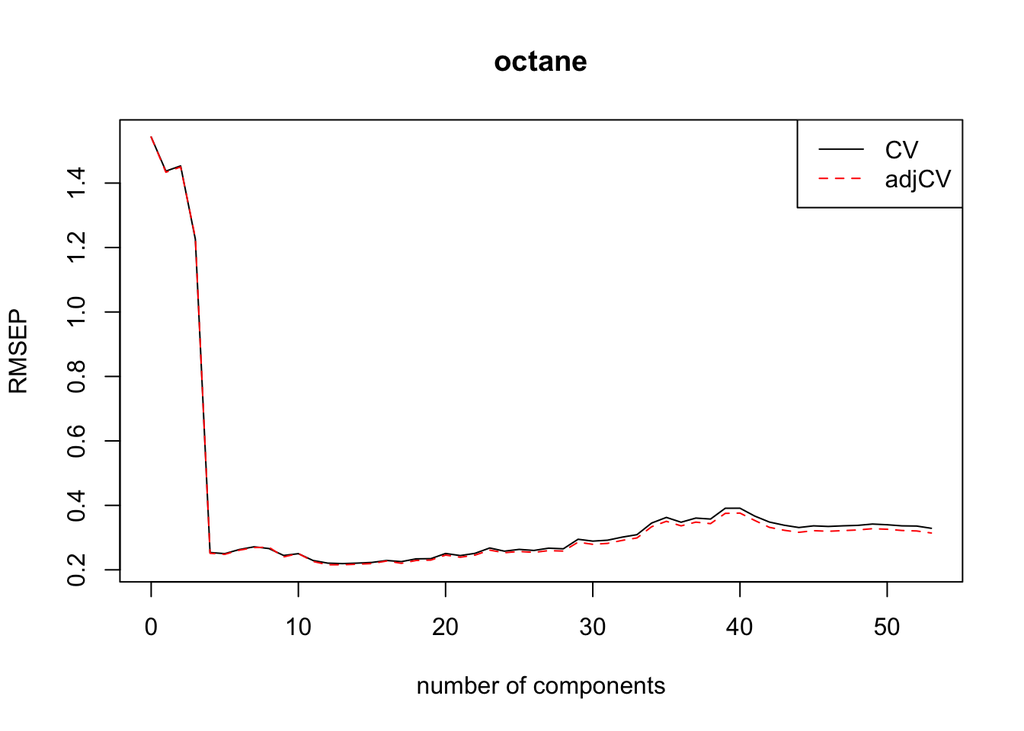

```r
plot(RMSEP(gasoline.pcr), legendpos = "topright")
```

From this, it looks like 4 components is sufficient. Using more than 4 components doesn’t lead to big decreases in the cross-validation error, and can even result in larger prediction errors.

4. Now try ridge regression. What value would you choose for the ridge penalty term $\lambda$?

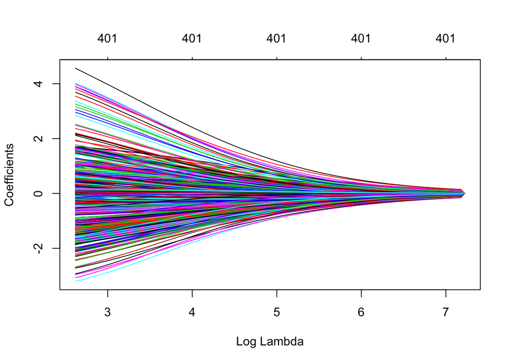

```r
library(glmnet)
gas.ridge <- glmnet(gasoline$NIR, gasoline$octane, alpha=0)
plot(gas.ridge, xvar='lambda')
```

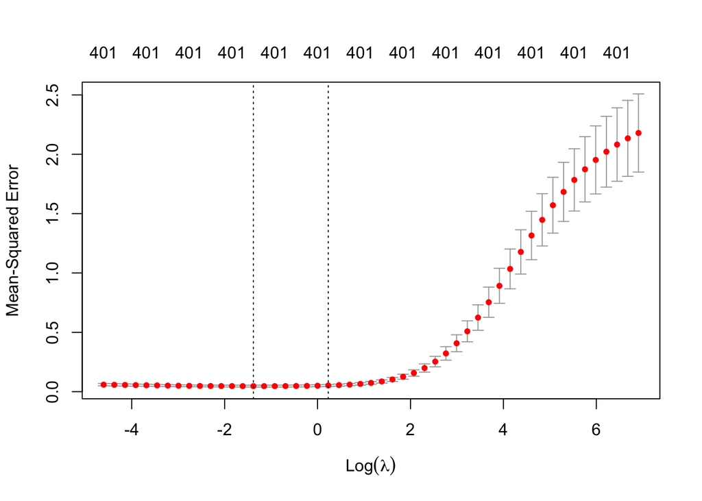

```r
lambdas <- 10^seq(3,-2,by=-0.1)
cv_fit <- cv.glmnet(gasoline$NIR, gasoline$octane, alpha = 0, lambda = lambdas)
plot(cv_fit)
```

We usually pick $\lambda$ to be the value which achieves the smallest MSE

```r
cv_fit$lambda.min
```

```
## [1] 0.2511886
```

or the largest value of $\lambda$ that gives a prediction error within one standard deviation of the minimum:

```r
cv_fit$lambda.1se
```

```
## [1] 1.258925
```

We can extract the coefficients for a given value of lambda as follows:

```r
coef(glmnet(gasoline$NIR, gasoline$octane, alpha=0, lambda=cv_fit$lambda.1se))
```

[output not shown]

##### Q2

The `lm` command in R will automatically work if you pass in a matrix of response variables. To demonstrate this, lets try to predict the sepal width and sepal length from the petal length and widths for the iris data.

```r
lm(cbind(Sepal.Length, Sepal.Width) ~ Petal.Length+Petal.Width, data=iris)
```

```
##
## Call:
## lm(formula = cbind(Sepal.Length, Sepal.Width) ~ Petal.Length +
##     Petal.Width, data = iris)
##
## Coefficients:
##               Sepal.Length  Sepal.Width
## (Intercept)    4.1906        3.5870
## Petal.Length   0.5418       -0.2571
## Petal.Width   -0.3196        0.3640
```

Check that the parameter estimates you find are the same as if you did two univariate linear regressions.

```r
lm(Sepal.Length ~ Petal.Length+Petal.Width, data=iris)
```

```
##
## Call:
## lm(formula = Sepal.Length ~ Petal.Length + Petal.Width, data = iris)
##
## Coefficients:
##  (Intercept)  Petal.Length   Petal.Width
##       4.1906        0.5418       -0.3196
```

```r
lm(Sepal.Width ~ Petal.Length+Petal.Width, data=iris)
```

```
##
## Call:
## lm(formula = Sepal.Width ~ Petal.Length + Petal.Width, data = iris)
##
## Coefficients:
##  (Intercept)  Petal.Length   Petal.Width
##       3.5870       -0.2571        0.3640
```